# R Notebook

# **Inference for numerical data - Part 1**

# **Darshan Siddhpura**

## **Student ID: 0774684**

### Load packages

In this lab we will explore the data using the dplyr package and visualize it using the ggplot2 package for data visualization.

Let’s load the packages.

```r
library(tidyverse)
library(here)
library(oilabs)
```

### **The data**

In 2004, the state of North Carolina released a large data set containing information on births recorded in this state. This data set is useful to researchers studying the relation between habits and practices of expectant mothers and the birth of their children. We will work with a random sample of observations from this data set.

Load the `nc` data set.

```r
nc <- read_csv(here('data', 'ncbirths.csv'))
```

We have observations on 12 different variables, some categorical and some numerical. The meaning of each variable can be found in the separate documentation file `ncbirths_documentation.txt`.

## **1. What are the cases/observations in this data set? How many cases/observations are there in our sample?**

```r
summary(nc)
```

```
##       fage            mage       mature              weeks
##  Min.   :14.00   Min.   :13   Length:1000        Min.   :20.00
##  1st Qu.:25.00   1st Qu.:22   Class :character   1st Qu.:37.00
##  Median :30.00   Median :27   Mode  :character   Median :39.00
##  Mean   :30.26   Mean   :27                      Mean   :38.33
##  3rd Qu.:35.00   3rd Qu.:32                      3rd Qu.:40.00
##  Max.   :55.00   Max.   :50                      Max.   :45.00
##  NA's   :171                                     NA's   :2
##     premie              visits        marital          gained
##  Length:1000        Min.   : 0.0   Min.   :1.000   Min.   : 0.00
##  Class :character   1st Qu.:10.0   1st Qu.:1.000   1st Qu.:20.00
##  Mode  :character   Median :12.0   Median :1.000   Median :30.00
##                     Mean   :12.1   Mean   :1.386   Mean   :30.33
##                     3rd Qu.:15.0   3rd Qu.:2.000   3rd Qu.:38.00
##                     Max.   :30.0   Max.   :2.000   Max.   :85.00
##                     NA's   :9      NA's   :1       NA's   :27
##      weight       lowbirthweight        gender             habit
##  Min.   : 1.000   Length:1000        Length:1000        Length:1000
##  1st Qu.: 6.380   Class :character   Class :character   Class :character
##  Median : 7.310   Mode  :character   Mode  :character   Mode  :character
##  Mean   : 7.101
##  3rd Qu.: 8.060
##  Max.   :11.750
##
```

```r
nrow(nc)
```

```
## [1] 1000
```

### **Answer:**

- Each observation is representing birth of each baby in North Carolina state.
- Total number of observations is 1000.

## **Exploratory data analysis**

We will first start with analyzing the weight gained by mothers throughout the pregnancy: `gained`.

## **2. Using visualization and summary statistics, describe the distribution of weight gained by mothers during pregnancy.**

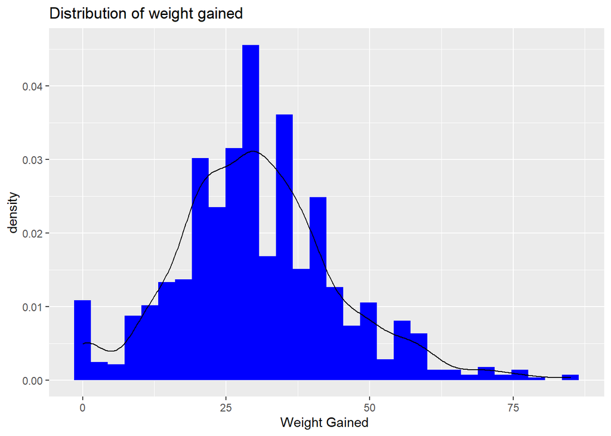

```r
nc %>%
  ggplot(aes(gained))+
  geom_histogram(aes(y = ..density..), fill = "blue", bins=30)+
  geom_density()+
  theme_gray()+
  labs(
    title = "Distribution of weight gained",
    x = "Weight Gained "
  )
```

```r
summary(nc$gained)
```

```
##    Min. 1st Qu.  Median    Mean 3rd Qu.    Max.    NA's
##    0.00   20.00   30.00   30.33   38.00   85.00      27
```

### **Answer:**

- The distribution of weight gained by mothers during pregnancy is nearly distributed normal only.
- Also having similar mean and median.

## **3. How many mothers are we missing weight gain data for?**

```r
sum(is.na(nc$gained))
```

```
## [1] 27
```

### **Answer:**

- There are 27 mothers for whom we are missing weight gain data.

Next, consider the possible relationship between a mother’s smoking habit and the weight of her baby. Plotting the data is a useful first step because it helps us quickly visualize trends, identify strong associations, and develop research questions.

## **4. Make a side-by-side boxplot of `habit` and `weight`. What does the plot highlight about the relationship between these two variables?**

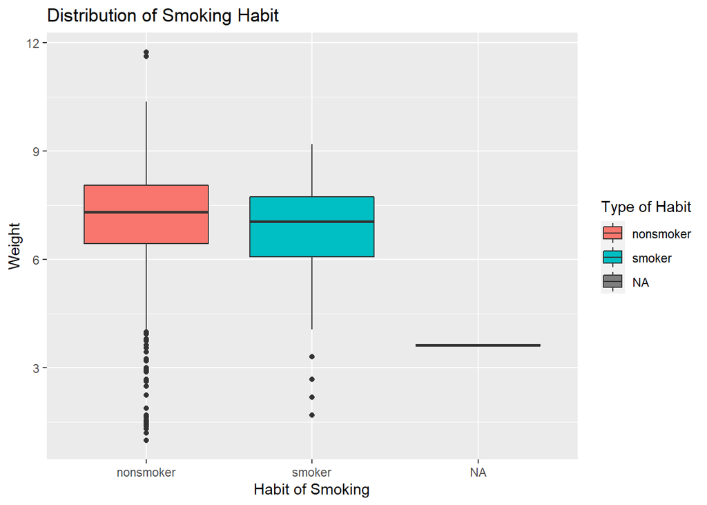

```r
nc$habit <- factor(nc$habit)

nc %>%
  ggplot(aes(y= weight, x=habit, fill = habit))+
  geom_boxplot()+
  theme_gray()+
  labs(
    title = "Distribution of Smoking Habit",
    x = "Habit of Smoking",
    y = "Weight"
  ) + guides(fill=guide_legend(title="Type of Habit"))
```

### **Answer:**

- From the above visualization, it seems that Weight and type of habit has the positive relationship since smoking habit affects the weight of the person or a baby.
- Babies born from nonsmokers are having the higher weight than babies born from smokers.

The box plots show how the medians of the two distributions compare, but we can also compare the means of the distributions.

## **5. Calculate the mean `weight` and standard deviation for each group of the `habit` variable. Remove any missing values for `habit`.**

```r
sum(is.na(nc))
```

```
## [1] 213
```

```r
nc1 <- nc %>% drop_na(habit)

nc1 %>%
  group_by(habit) %>%
  summarize(weight_mean = mean(weight), sd_weight = sd(weight))
```

| habit | weight_mean | sd_weight |
| --- | --- | --- |
| nonsmoker | 7.144273 | 1.518681 |
| smoker | 6.828730 | 1.386180 |

There is an observed difference, but is this difference statistically significant? That is, is this observed difference due to chance (`habit` and `weight` are independent of each other) or can we infer that `habit` and `weight` are dependent? In order to answer this question we will conduct a hypothesis test.

## **6. Are all conditions necessary for inference satisfied? Comment on each. You can compute the group sizes with the `summarize` command above by defining a new variable with the definition `n()`.**

```r
nc1 %>%
  group_by(habit) %>%
  summarize(weight_mean = mean(weight), sd_weight = sd(weight), observation = n())
```

| habit | weight_mean | sd_weight | observation |
| --- | --- | --- | --- |
| nonsmoker | 7.144273 | 1.518681 | 873 |
| smoker | 6.828730 | 1.386180 | 126 |

### **Answer:**

#### **Conditions for inference to be satisfied:**

- **Independence**: The data is a simple random sample of North Carolina, which means that the observations are independent. Sample has been taken randomly which shows the independence between the samples of two variables.
- **Normal Distribution**: For both smoker and nonsmoker n>=10 and hence the distribution will be approximately normal. Also, n>30 hence both distributions are almost symmetric and not heavily skewed.

## **7. Write the hypotheses for testing if the average weights of babies born to smoking and non-smoking mothers are different.**

### **Answer:**

- The null hypothesis represents the case of no difference between the groups.
- H0: There is no difference in average birth weight for newborns from mothers who did and did not smoke. In statistical term: µn − µs = 0, where µn represents non-smoking mothers and µs represents mothers who smoked.
- HA: There is some difference in average newborn weights from mothers who did and did not smoke (µn − µs != 0).

Next, we introduce a new function, `inference`, that we will use for conducting hypothesis tests and constructing confidence intervals.

```r
inference(y = weight, x = habit, data = nc, statistic = "mean", type = "ht", null = 0,
          alternative = "twosided", method = "theoretical")
```

```
## Response variable: numerical
## Explanatory variable: categorical (2 levels)
## n_nonsmoker = 873, y_bar_nonsmoker = 7.1443, s_nonsmoker = 1.5187
## n_smoker = 126, y_bar_smoker = 6.8287, s_smoker = 1.3862
## H0: mu_nonsmoker =  mu_smoker
## HA: mu_nonsmoker != mu_smoker
## t = 2.359, df = 125
## p_value = 0.0199
```

[figure not shown]

```r
t.test(weight~habit,data=nc,conf.level=0.90)
```

```
##
##  Welch Two Sample t-test
##
## data:  weight by habit
## t = 2.359, df = 171.32, p-value = 0.01945
## alternative hypothesis: true difference in means is not equal to 0
## 90 percent confidence interval:
##  0.09432986 0.53675506
## sample estimates:
## mean in group nonsmoker    mean in group smoker
##                7.144273                6.828730
```

```r
mean_s<-nc %>% na.omit(weight) %>% filter(habit=="smoker") %>% summarise(point_estimate = mean(weight))
mean_ns<-nc %>% na.omit(weight) %>% filter(habit=="nonsmoker") %>% summarise(point_estimate = mean(weight))
point_estimate=mean_ns-mean_s
point_estimate
```

| point_estimate |
| --- |
| 0.3621787 |

## **9. Using the above output from the `inference` function, calculate the *standard error* of the estimate.**

```r
standard_error <- point_estimate/2.359
standard_error
```

| point_estimate |
| --- |
| 0.1535306 |

## **10. Change the `type` argument to `"ci"` to construct and record a confidence interval for the difference between the weights of babies born to nonsmoking and smoking mothers, and interpret this interval in context of the data. Note that by default you’ll get a 95% confidence interval. If you want to change the confidence level, add a new argument (`conf_level`) which takes on a value between 0 and 1. Also note that when doing a confidence interval arguments like `null` and `alternative` are not useful, so make sure to remove them.**

```r
inference(y = weight, x = habit, data = nc, statistic = "mean", type = "ci",
          method = "theoretical")
```

```
## Response variable: numerical, Explanatory variable: categorical (2 levels)
## n_nonsmoker = 873, y_bar_nonsmoker = 7.1443, s_nonsmoker = 1.5187
## n_smoker = 126, y_bar_smoker = 6.8287, s_smoker = 1.3862
## 95% CI (nonsmoker - smoker): (0.0508 , 0.5803)
```

```r
inference(y = weight, x = habit, data = nc, statistic = "mean", type = "ci",
          method = "theoretical", order = c("smoker","nonsmoker"))
```

```
## Response variable: numerical, Explanatory variable: categorical (2 levels)
## n_smoker = 126, y_bar_smoker = 6.8287, s_smoker = 1.3862
## n_nonsmoker = 873, y_bar_nonsmoker = 7.1443, s_nonsmoker = 1.5187
## 95% CI (smoker - nonsmoker): (-0.5803 , -0.0508)
```

#### **For 90% confidence interval:**

```r
inference(y = weight, x = habit, data = nc, statistic = "mean", type = "ci", conf_level = 0.90 ,method = "theoretical")
```

```
## Response variable: numerical, Explanatory variable: categorical (2 levels)
## n_nonsmoker = 873, y_bar_nonsmoker = 7.1443, s_nonsmoker = 1.5187
## n_smoker = 126, y_bar_smoker = 6.8287, s_smoker = 1.3862
## 90% CI (nonsmoker - smoker): (0.0939 , 0.5372)
```